# Guided Project: Scales and Facets

CIS-3901 · Module 13

Author

Eric Torralba

Published

November 17, 2026

**ImportantEdit the code in the script. The report and the slides only read it.**

The code lives in `scripts/gp13_scales_facets.R`. Your words (findings, headlines, limits) live in the report and the slides. Keep the code chunks here empty: on render, each one runs the script’s code, so code typed into them is ignored. Fix the code in the script.

## My data

Fairness dataset. (2026). Dataset provided for CIS-3901 Guided Project, Catawba College

```r
put_in_place("fairness.csv")
put_in_place("sports.csv")

fairness <- read_csv("data/fairness.csv", show_col_types = FALSE)
sports <- read_csv("data/sports.csv", show_col_types = FALSE)

if (looks_damaged(fairness) || looks_damaged(sports)) {
  stop("One of your data files looks damaged (each row in one column): it ",
       "may have been re-saved by a spreadsheet app. Ask your instructor ",
       "for a fresh copy.", call. = FALSE)
}

# Your columns ("values" = how many different values: 2 to 4 suits
# task 5). Never put a column of people's names in a plot.
show_columns(fairness)
```

```
# A tibble: 22 × 4
   column              type      values missing
   <chr>               <chr>      <int>   <int>
 1 encounter_id        numeric     5000       0
 2 race                character      6       0
 3 gender              character      3       0
 4 age                 character      3       0
 5 time_in_hospital    numeric       14       0
 6 num_lab_procedures  numeric       99       0
 7 num_procedures      numeric        7       0
 8 num_medications     numeric       63       0
 9 number_diagnoses    numeric       11       0
10 primary_diagnosis   character      5       0
11 max_glu_serum       character      4       0
12 A1Cresult           character      4       0
13 insulin             character      4       0
14 change              character      2       0
15 diabetesMed         character      2       0
16 medicare            logical        2       0
17 medicaid            logical        2       0
18 had_emergency       logical        2       0
19 had_inpatient_days  logical        2       0
20 had_outpatient_days logical        2       0
21 readmitted          character      3       0
22 readmit_30_days     numeric        2       0
```

```r
show_columns(sports)
```

```
# A tibble: 10 × 4
   column     type      values missing
   <chr>      <chr>      <int>   <int>
 1 Rank       character    113       0
 2 Rikishi    character    565       0
 3 Heya       character     69       0
 4 Shusshin   character     61       0
 5 Birth Date character    547       0
 6 height_cm  numeric      112       0
 7 weight_kg  numeric      393       0
 8 wins       numeric       16       0
 9 losses     numeric       16       0
10 ties       numeric       16       0
```

```r
# PART A · FAIRNESS ==========================================================

# A0 · See it update ---------------------------------------------------------
# A ready count plot of one of your Fairness columns. Nothing to code.
# YOUR TURN (kickoff): change one word in the title, then render the report
# and the slides, and find your word on both pages.
```

## Part A · Fairness

### A0 · See it update

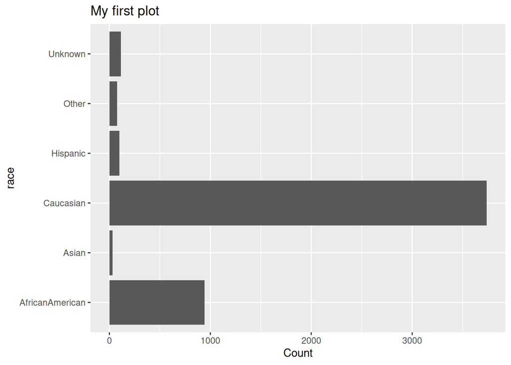

Figure 1: Healthcare Groups Overview: count of records by category.

```r
a0_column <- pick_a_column(fairness)

a0 <- ggplot(fairness, aes(y = .data[[a0_column]])) +
  geom_bar() +
  labs(title = "My first plot", x = "Count", y = a0_column)

show_plot(a0)
```

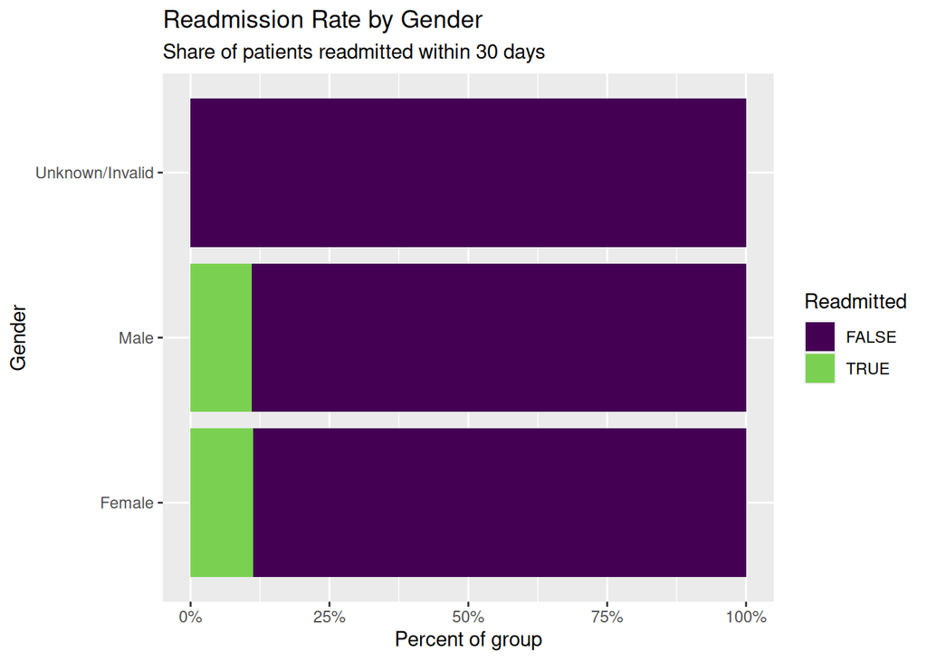

Figure 2: Share of each group with the outcome, labeled for a reader.

```r
a_data <- fairness %>%
  mutate(
    group = gender,
    has_outcome =
      readmit_30_days == 1
  )

a1_base <- ggplot(a_data,
                  aes(y = group, fill = has_outcome))+
  geom_bar(position = "fill")

a1 <- a1_base +
  labs(
    title = "Readmission Rate by Gender",
    subtitle = "Share of patients readmitted within 30 days",
    x = "Percent of group",
    y = "Gender",
    fill = "Readmitted"
  ) +
  scale_x_continuous(labels = scales::percent)

show_plot(a1)
```

WRITE (2 sentences): Which label did you change most, and why? Could a reader understand this plot without you there?

I changed the title the most because I wanted it to clearly explain what the chart shows. Yes, the labels make the plot easy to understand without me there.

### A2 · Choose a scale

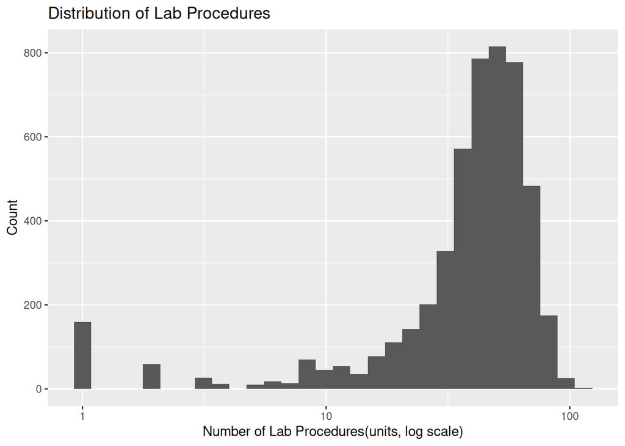

Figure 3: My scale choice.

```r
a2 <- NULL
# YOUR TURN: remove the # signs below, then replace each ___.
 a2 <- fairness %>%
 filter(num_lab_procedures> 0) %>%
 ggplot(aes(x = num_lab_procedures)) +
 geom_histogram(bins = 30) +
 scale_x_log10(labels = scales::comma) +
 labs(title = "Distribution of Lab Procedures", x = "Number of Lab Procedures(units, log scale)", y = "Count")

# YOUR TURN: one sentence. Why this scale for this column?
a2_reason <- "I used a log scale because num_lab_procedures is skewed, with many smaller values and fewer larger values. "

show_plot(a2)
```

WRITE (2–3 sentences): Which scale, and why? What does a reader see with it that they wouldn’t see without it? If values were removed (0 or below on a log scale), say how many.

I used a log scale because the data are spread out. It makes the pattern easier to see, and values of 0 were removed because a log scale cannot show zero.

### A3 · Facet it: fixed or free

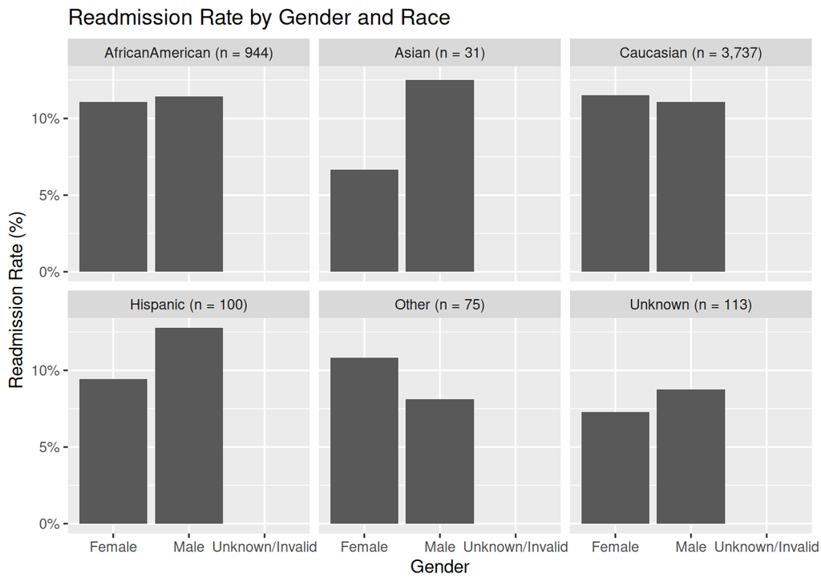

(a) Fixed

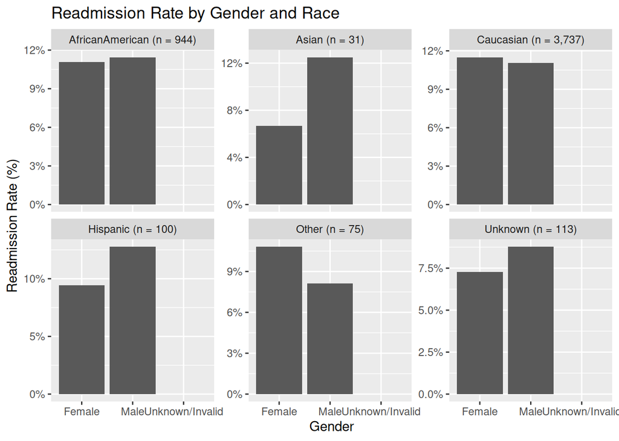

(b) Free

Figure 4: The same rates in panels: fixed and free y-axes.

```r
# YOUR TURN 1: replace "replace me" with your second column (no quotes).
a3_rates <- a_data %>%
  mutate(panel = race) %>%
  drop_na(has_outcome) %>%
  add_count(panel, name = "panel_n") %>%
  mutate(panel = paste0(panel, " (n = ", scales::comma(panel_n), ")")) %>%
  group_by(panel, group) %>%
  summarize(n = n(), rate = mean(has_outcome), .groups = "drop")

a3_fixed <- ggplot(a3_rates,aes(x = group, y = rate))+
  geom_col()+
  facet_wrap(vars(panel))+
  scale_y_continuous(labels = scales::percent)+
  labs(
    title = "Readmission Rate by Gender and Race",
    x = "Gender",
    y = "Readmission Rate (%)"
  )
a3_free <- a3_fixed +
  facet_wrap(vars(panel),
             scales = "free_y")
# YOUR TURN 2: remove the # signs below, then replace each ___.
# a3_fixed <- ggplot(a3_rates, aes(x = group, y = rate)) +
#   geom_col() +
#   facet_wrap(vars(panel)) +
#   scale_y_continuous(labels = scales::percent) +
#   labs(title = "___", x = "___", y = "___ (%)")
# a3_free <- a3_fixed +
#   facet_wrap(vars(panel), scales = "free_y")

# YOUR TURN 3: which one would you publish, "fixed" or "free_y"? Why?
a3_choice <- "fixed"
a3_reason <- "I would publish the fixed version because all panels use the same y-axis scale, making it easier to compare readmission rates across races."

show_plot(a3_fixed)
show_plot(a3_free)
```

Table 1: Each group’s n and rate, by panel.

| panel | group | n | rate |
| --- | --- | --- | --- |
| AfricanAmerican (n = 944) | Female | 577 | 0.111 |
| AfricanAmerican (n = 944) | Male | 367 | 0.114 |
| Asian (n = 31) | Female | 15 | 0.067 |
| Asian (n = 31) | Male | 16 | 0.125 |
| Caucasian (n = 3,737) | Female | 1948 | 0.115 |
| Caucasian (n = 3,737) | Male | 1789 | 0.111 |
| Hispanic (n = 100) | Female | 53 | 0.094 |
| Hispanic (n = 100) | Male | 47 | 0.128 |
| Other (n = 75) | Female | 37 | 0.108 |
| Other (n = 75) | Male | 37 | 0.081 |
| Other (n = 75) | Unknown/Invalid | 1 | 0.000 |
| Unknown (n = 113) | Female | 55 | 0.073 |
| Unknown (n = 113) | Male | 57 | 0.088 |
| Unknown (n = 113) | Unknown/Invalid | 1 | 0.000 |

WRITE (3–4 sentences): Fixed or free? What does the reader gain, and what do they lose? Which panels or groups are small, and what is their n? Describe differences, not causes.

I chose the fixed version because it makes the panels easier to compare. The reader can quickly see differences between groups because all panels use the same scale. Smaller groups have lower n values, which are shown in the panel labels. The plot shows differences in readmission rates across groups, but it does not explain why those differences exist.

### A4 · Compared to what?

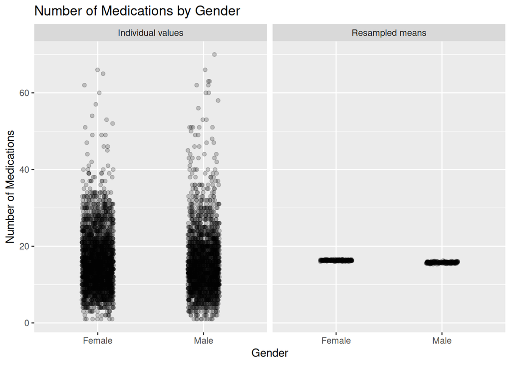

Figure 5: Two groups: individual values and resampled means, same axes.

```r
a4_clouds <- a_data %>%
  filter(group %in% c("Male", "Female")) %>%
  make_clouds(group, num_medications)

# YOUR TURN 1: remove the # signs below, then replace each ___: the column
# with your groups, two of its values, and your numeric column.
# a4_clouds <- a_data %>%
#   filter(___ %in% c("___", "___")) %>%
#   make_clouds(___, ___)

a4 <- ggplot(a4_clouds, aes(x = group, y = value)) +
  geom_jitter(width = 0.15, height = 0, alpha = 0.2) +
  facet_wrap(~ kind) +
  labs(
    title = "Number of Medications by Gender",
    x = "Gender",
    y = "Number of Medications"
  )
# YOUR TURN 2: remove the # signs below, then replace each ___.
# a4 <- ggplot(a4_clouds, aes(x = group, y = value)) +
#   geom_jitter(width = 0.15, height = 0, alpha = 0.2) +
#   facet_wrap(~ kind) +
#   labs(title = "___", x = "___", y = "___ (units)")

show_plot(a4)
```

WRITE (2–3 sentences): Do the clouds overlap? What does that say about individuals versus the group means?

The clouds overlap quite a bit between the two groups. This suggests that many individual patients have similar values, even though the group averages may be slightly different.

### A5 · Color for every reader

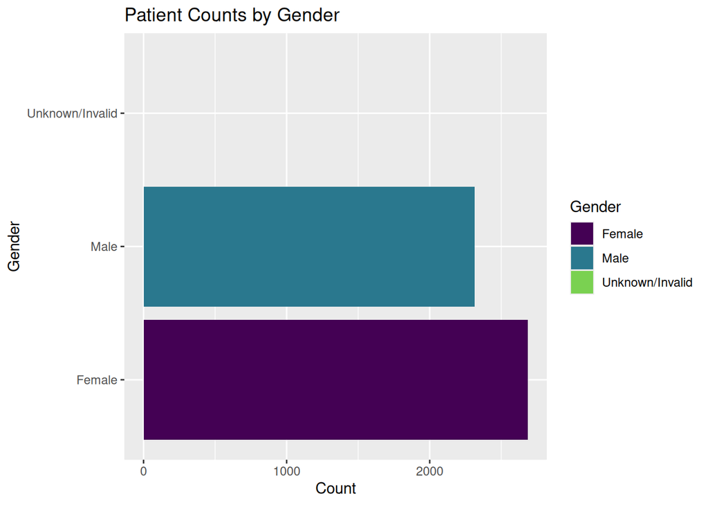

(a) My plot

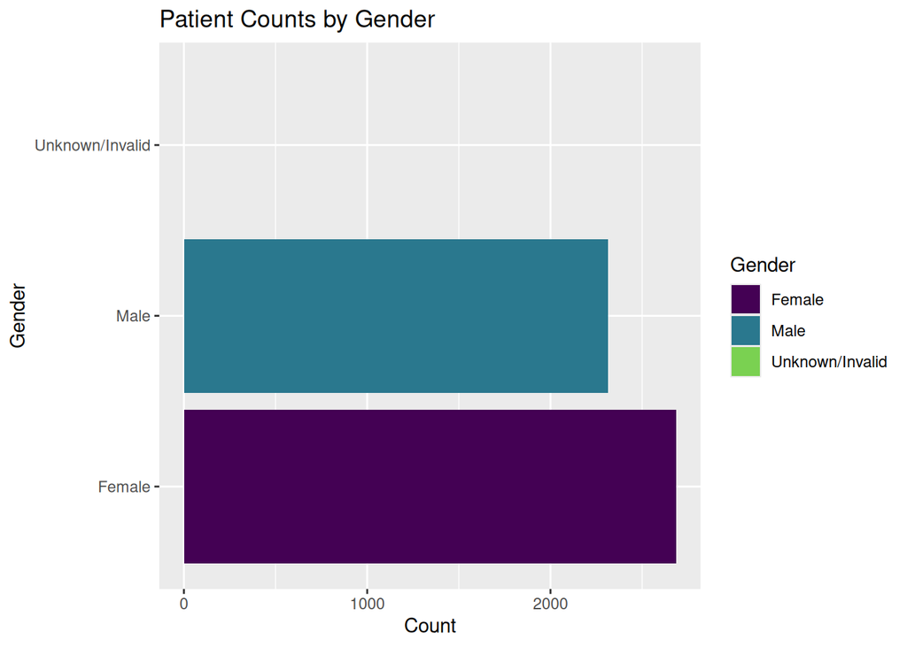

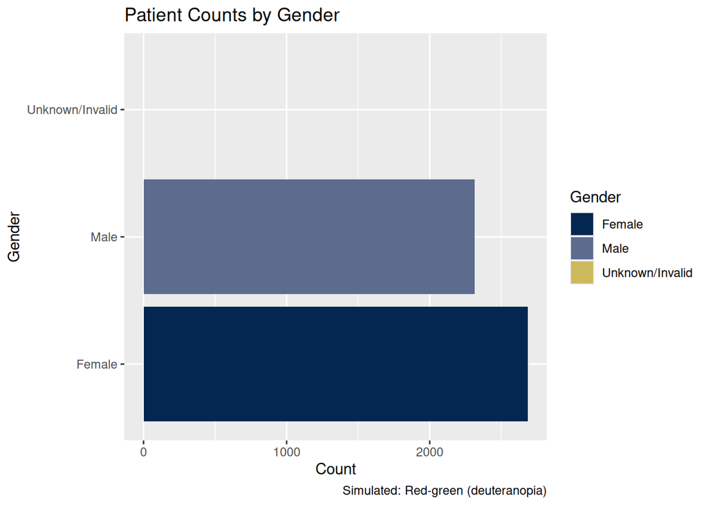

Figure 6: My colors, with a second cue, and how a reader with red-green color blindness might see them.

```r
a5 <- ggplot(a_data, aes(y = group, fill = group)) +
  geom_bar() +
  scale_fill_viridis_d(end = 0.8) +
  labs(
    title = "Patient Counts by Gender",
    x = "Count",
    y = "Gender",
    fill = "Gender"
  )

show_plot(a5)
# YOUR TURN: remove the # signs below, then replace each ___ (the same
# column in both places, so its name is on the axis too).
# a5 <- ggplot(a_data, aes(y = ___, fill = ___)) +
#   geom_bar() +
#   scale_fill_viridis_d(end = 0.8) +
#   labs(title = "___", x = "Count", y = "___", fill = "___")

show_plot(a5)
# See it: your plot as a reader with red-green color blindness might see it.
show_plot(simulate_plot(a5, "Red-green (deuteranopia)"))
```

```r
color_check(a5)
```

```
3 colors. The red-green simulations come from a validated model;
the blue-yellow one is an approximation.
```

```
# A tibble: 3 × 3
  view                      smallest_difference at_least_20
  <chr>                                   <dbl> <chr>
1 Red-green (deuteranopia)                 30.5 Yes
2 Red-green (protanopia)                   41.1 Yes
3 Blue-yellow (approximate)                29.7 Yes
```

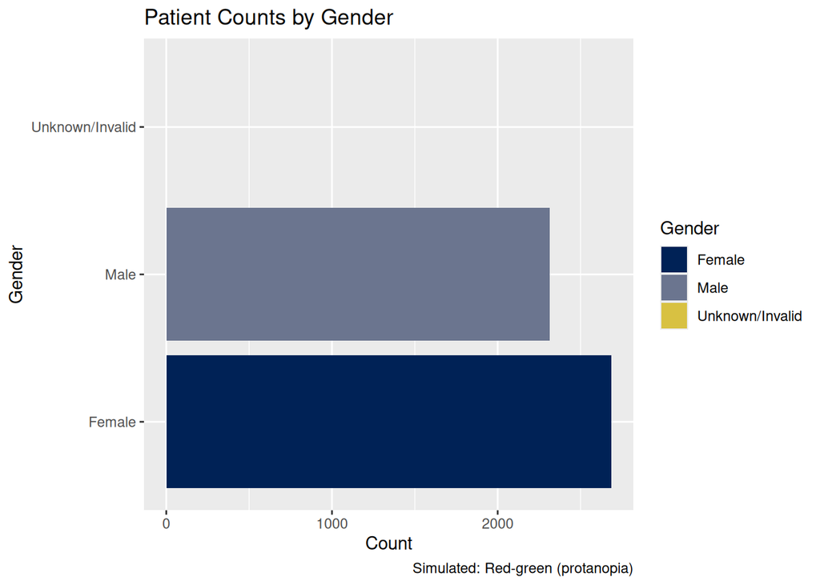

(a) Red-green (protanopia), simulated

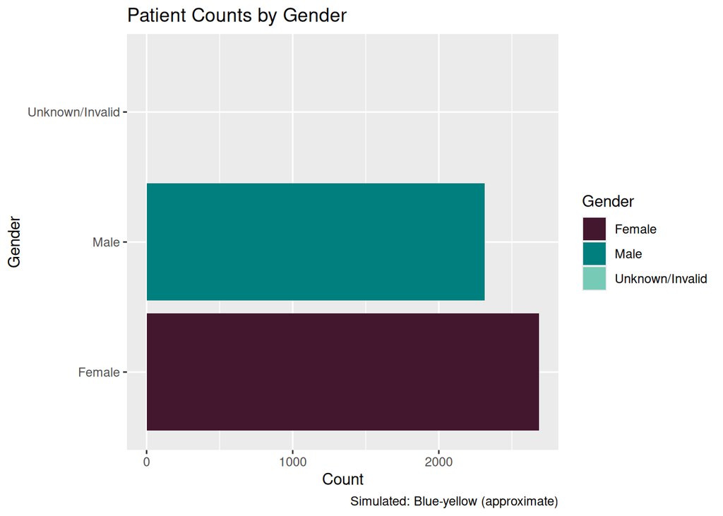

(b) Blue-yellow (approximate), simulated

Figure 7: The other two simulated views.

```r
show_plot(simulate_plot(a5, "Red-green (protanopia)"))
show_plot(simulate_plot(a5, "Blue-yellow (approximate)"))
```

WRITE (2–4 sentences): Explain your colors. Say which column you colored by and why. If your first choice failed the color check, say what you changed: fewer categories, grouping rare ones, or panels. Then look at your simulated plot: can you still tell the categories apart?

I colored the plot by gender to compare the two groups. I used a color-blind-friendly palette so the colors are easy to distinguish. The gender labels also help identify the groups without relying only on color. Yes, I can still tell the categories apart in the simulated plot.

## Part B · Sports

### B1 · Label it

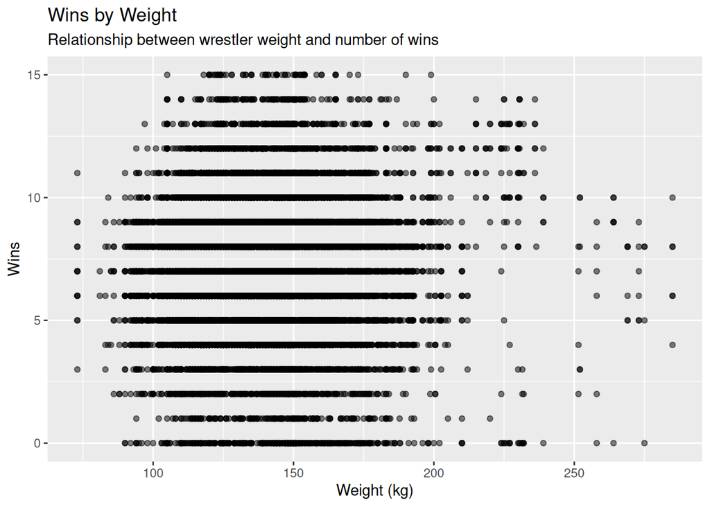

Figure 8: My Sports plot, labeled for a reader.

```r
b_data <- sports %>%
  mutate(
    group = "Heya",
    has_outcome = wins > losses,
    value = wins
  )

b1_base <- ggplot(b_data,
                  aes(x = weight_kg, y = wins))+
  geom_point(alpha = 0.5)

b1 <- b1_base +
  labs(
    title = "Wins by Weight",
    subtitle = "Relationship between wrestler weight and number of wins",
    x = "Weight (kg)",
    y = "Wins"
  )

show_plot(b1)
```

WRITE (2 sentences): What does the plot show? Which label helps a reader most?

The plot shows the relationship between wrestler weight and the number of wins. The axis labels help a reader the most because they clearly show what is being compared.

### B2 · Choose a scale

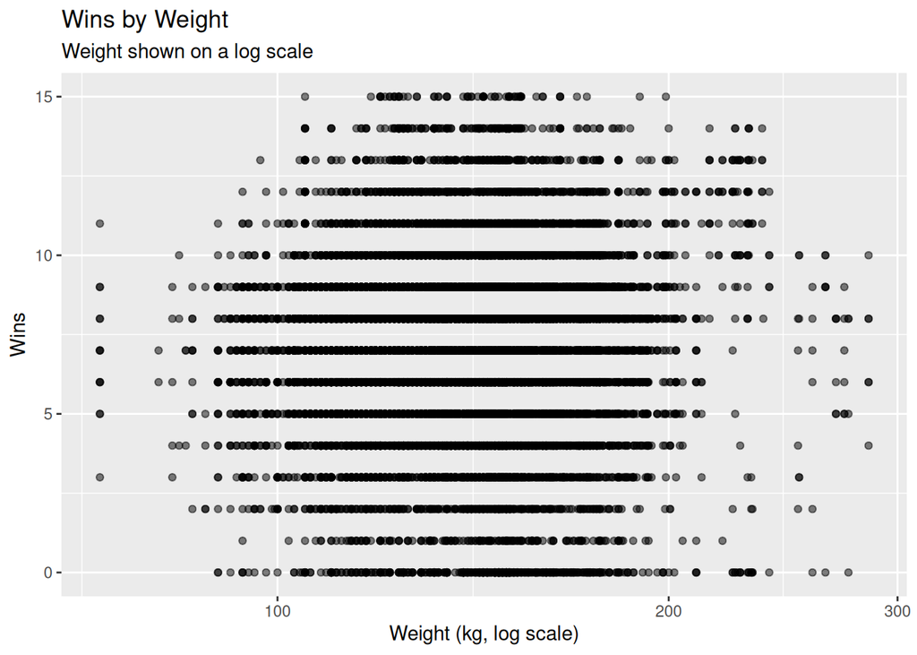

Figure 9: My scale choice.

```r
b2 <- b1_base +
  scale_x_log10()+
  labs(
    title = "Wins by Weight",
    subtitle = "Weight shown on a log scale",
    x = "Weight (kg, log scale)",
    y = "Wins"
  )

b2_reason <- "A log scale helps reduce the effect of extreme weight values and makes the overall pattern easier to see."

show_plot(b2)
```

WRITE (2–3 sentences): Which scale, and why? If values were removed, say how many.

I used a log scale for wrestler weight because it makes the data easier to read. The log scale helps show the overall pattern in the data more clearly. No values were removed.

### B3 · Facet it: fixed or free

[figure not shown]

(a) Fixed

[figure not shown]

(b) Free

```r
heya_counts <- sports %>%
  count(Heya) %>%
  mutate(
    label = paste0(Heya, " (n = ", scales::comma(n), ")")
  )

b3_data <- sports %>%
  left_join(
    heya_counts %>% select(Heya, label),
    by = "Heya"
  )

b3_fixed <- ggplot(b3_data, aes(x = weight_kg, y = wins)) +
  geom_point(alpha = 0.5) +
  facet_wrap(~ label, scales = "fixed")

b3_free <- ggplot(b3_data, aes(x = weight_kg, y = wins)) +
  geom_point(alpha = 0.5) +
  facet_wrap(~ label, scales = "free")

b3_choice <- "fixed"

b3_reason <- "Fixed scales make it easier to compare the relationship between weight and wins across heya groups because every panel uses the same axis ranges."

show_plot(b3_fixed)
show_plot(b3_free)
```

WRITE (3–4 sentences): Fixed or free? What does the reader gain, and what do they lose? Which panels are small, and what is their n? Differences, not causes.

I chose the fixed version because it makes the heya groups easier to compare. The reader gains a consistent scale across all panels, but loses some detail that may be easier to see with free scales. The smaller panels have lower n values, which are shown in the panel labels. The plot shows differences between heya groups, but it does not explain the causes of those differences.

### B4 · Compared to what?

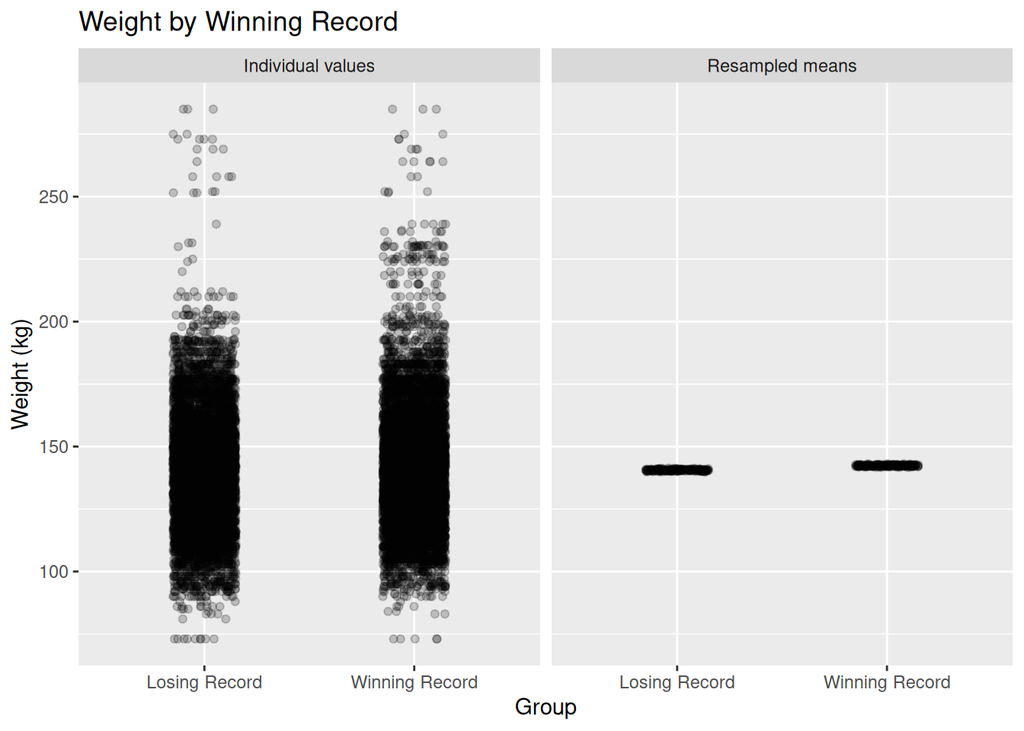

Figure 11: Two groups: individual values and resampled means, same axes.

```r
b4_clouds <- sports %>%
  filter(wins != losses) %>%
  mutate(group = if_else(wins > losses, "Winning Record", "Losing Record")) %>%
  make_clouds(group, weight_kg)

b4 <- ggplot(b4_clouds, aes(x = group, y = value)) +
  geom_jitter(width = 0.15, height = 0, alpha = 0.2) +
  facet_wrap(~ kind) +
  labs(
    title = "Weight by Winning Record",
    x = "Group",
    y = "Weight (kg)"
  )

show_plot(b4)
```

WRITE (2–3 sentences): Do the clouds overlap? What does that say about individuals versus the group means?

The clouds overlap quite a bit between the two groups. This suggests that many individual wrestlers have similar weights. The group means are more stable and show less variation than the individual values.

### B5 · Color for every reader

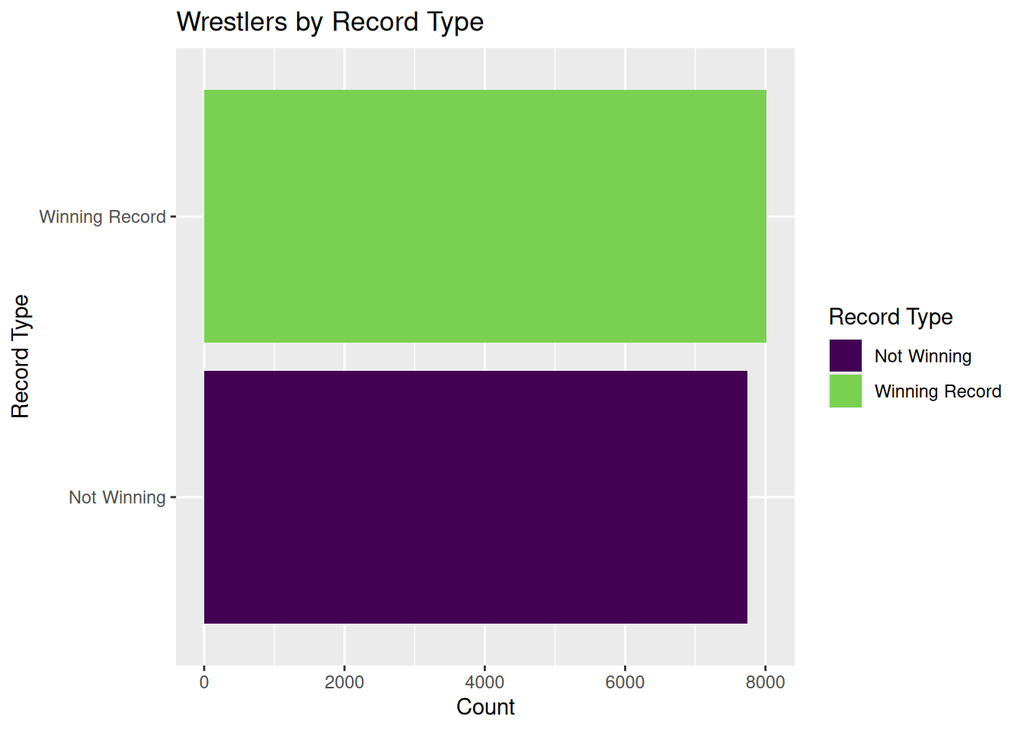

(a) My plot

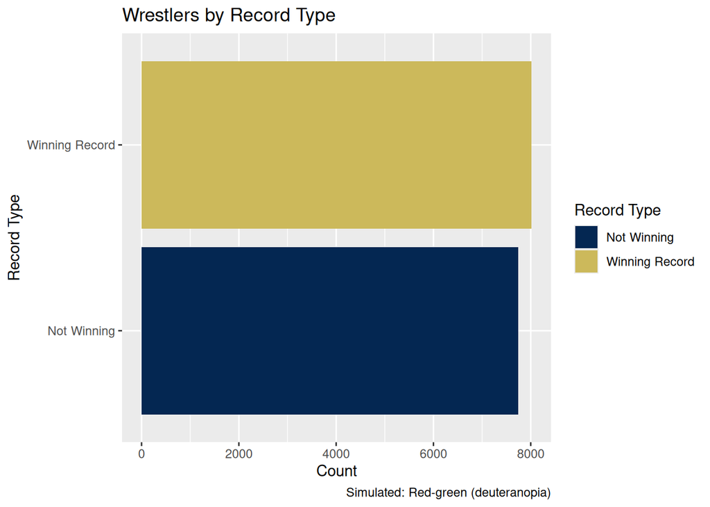

(b) Red-green (deuteranopia), simulated

Figure 12: My colors, with a second cue, and how a reader with red-green color blindness might see them.

```r
b5_data <- sports %>%
  mutate(
    record_type = if_else(wins > losses,
                          "Winning Record",
                          "Not Winning")
  )

b5 <- ggplot(b5_data,
             aes(y = record_type,
                 fill = record_type)) +
  geom_bar() +
  scale_fill_viridis_d(end = 0.8) +
  labs(
    title = "Wrestlers by Record Type",
    x = "Count",
    y = "Record Type",
    fill = "Record Type"
  )

show_plot(b5)
show_plot(simulate_plot(b5, "Red-green (deuteranopia)"))
```

```r
color_check(b5)
```

```
2 colors. The red-green simulations come from a validated model;
the blue-yellow one is an approximation.
```

```
# A tibble: 3 × 3
  view                      smallest_difference at_least_20
  <chr>                                   <dbl> <chr>
1 Red-green (deuteranopia)                 99.5 Yes
2 Red-green (protanopia)                  119.  Yes
3 Blue-yellow (approximate)                81.3 Yes
```

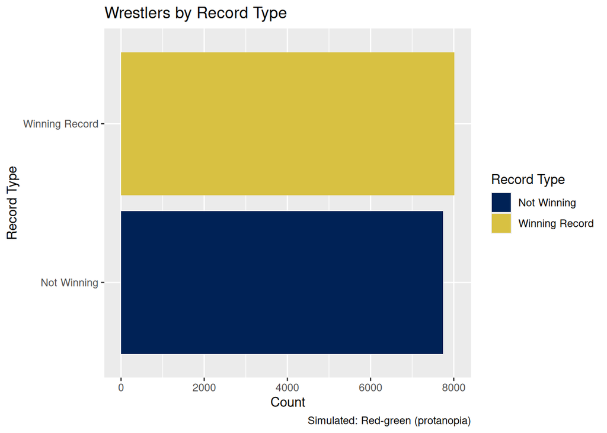

(a) Red-green (protanopia), simulated

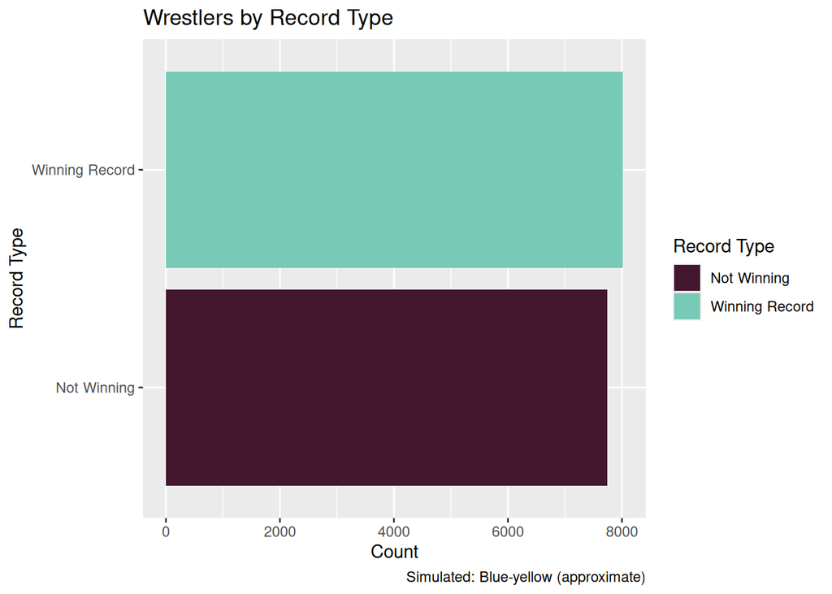

(b) Blue-yellow (approximate), simulated

Figure 13: The other two simulated views.

```r
show_plot(simulate_plot(b5, "Red-green (protanopia)"))
show_plot(simulate_plot(b5, "Blue-yellow (approximate)"))
```

WRITE (2–4 sentences): Explain your colors. Say which column you colored by and why. If your first choice failed the color check, say what you changed: fewer categories, grouping rare ones, or panels. Then look at your simulated plot: can you still tell the categories apart?

I colored the plot by record type to compare wrestlers with winning and non-winning records. I used a color-blind-friendly palette so the categories are easy to distinguish. The y-axis labels provide a second cue besides color. Yes, I can still tell the categories apart in the simulated plot.

## One thing I tried in my slides, and why

WRITE (2–3 sentences): One idea of your own in your slides (an angle, a comparison, an order, an annotation), and how it helps a reader see the finding.

Fill this in for the final: three to five changes to your report or slides. For each: what changed, why, and which idea from Module 14 it uses.

Change | Why | Module 14 idea |

|Improved chart titles and axis labels|Made the graphs easier for readers to understand without extra explanation|Clear labeling|

|Added descriptive figure captions and alt text |Improved accessibility and explained what each figure shows | Accessibility|

|Chose fixed scales for the faceted plots | Made comparisons between groups easier and more accurate|Fair comparison |

[output not shown]

## Checks

Table 2: Every task’s check, at the time this page was rendered.

| task | status |
| --- | --- |
| A0 | see the reminder |
| A1 | PASS |
| A2 | PASS |
| A3 | PASS |
| A4 | PASS |
| A5 | PASS |
| B1 | PASS |
| B2 | PASS |
| B3 | PASS |
| B4 | PASS |
| B5 | PASS |

## AI use

WRITE: one public line only: “AI use: I used [tool] to [what for].” or “AI use: none.” (Your AI log and conversations go in Blackboard, never here: Guided Project page.)

I used Microsoft Copilot to help interpret assignment requirements, troubleshoot R code, and create and refine charts and visualizations for this project